# Registro de Esclerosis Múltiple del Hospital Universitario Nacional de Colombia

## Investigadores

Simón Cárdenas Robledo

Laura Estefanía Arenas Vargas

Claudia Marcela Guío (2018-2024)

Lorena López

## Introducción

El registro de Esclerosis Múltiple (EM) del Hospital Universitario Nacional de Colombia (REMHUN) se inició en el año 2020, tras cuatro años de atención de pacientes con EM. El REMHUN es un estudio observacional, de diseño retrospectivo y prospectivo, que incluye pacientes con EM confirmada, pacientes con un primer episodio desmielinizante que no satisfacen criterios de EM (síndrome clínico aislado - CIS) y pacientes con lesiones en resonancia magnética de apariencia desmielinizante encontradas como hallazgo incidental (síndrome radiológico aislado - RIS).

Este estudio fue aprobado por el [Comité de Ética en Investigación del HUN](https://www.hun.edu.co/comite-de-etica) el 4 de febrero del año 2020 (CEI-HUN-acta-2019-12)

## Enrolamiento

A corte del 1 de octubre de 2024, de 783 pacientes vistos alguna vez en [nuestro centro](https://www.hun.edu.co/CEMHUN), 649 (82.9%) han aceptado voluntariamente su inclusión en el estudio y 623 de ellos (95.99%) cuentan con información completa y actualizada en el registro.

Nuestro registro cuenta con información clínica de visitas con determinación del puntaje EDSS, sobre recaídas, tratamientos modificadores de la EM (TMEs) y resonancias magnéticas.

Desde su primera visita en nuestro centro, los pacientes han tenido un seguimiento de 54.6 meses en promedio, para un acumulado de 2866.4 años/paciente.

Durante este tiempo se han hecho un total de 5265 determinaciones de EDSS, para un promedio de 8.4 determinaciones por paciente.

Contamos con información sobre 1410 recaídas y 5818 resonancias magnéticas, de las cuales 2594 son resonancias cerebrales.

## Datos demográficos

Los datos demográficos básicos de los pacientes incluídos se muestran a continuación:

### Sexo:

Como es usual en la Esclerosis Múltiple, en nuestro registro predominan las mujeres, con un 69.5% del total, para una relación mujer:hombre de 2.3:1.

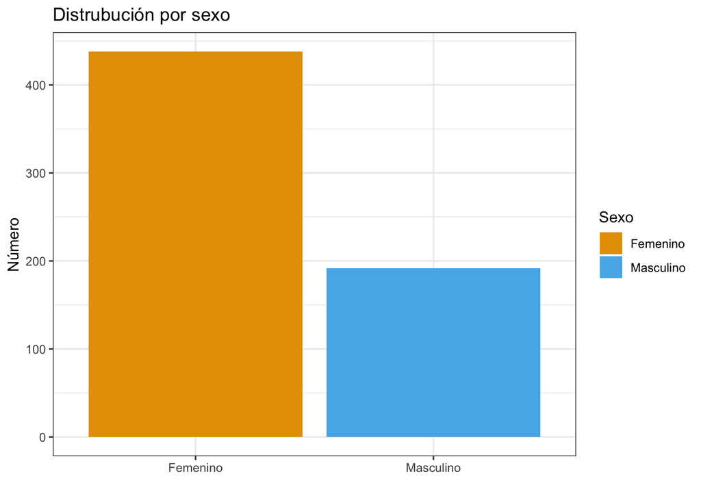

### Edad:

El grupo de pacientes reclutados tiene una edad promedio de 44.5 años, con una desviación estándar de 12.2 años. Las mujeres tienen una edad promedio de 44.7 y los hombres de 44.2 años. La distribución de edad de acuerdo al sexo se presenta a continuación:

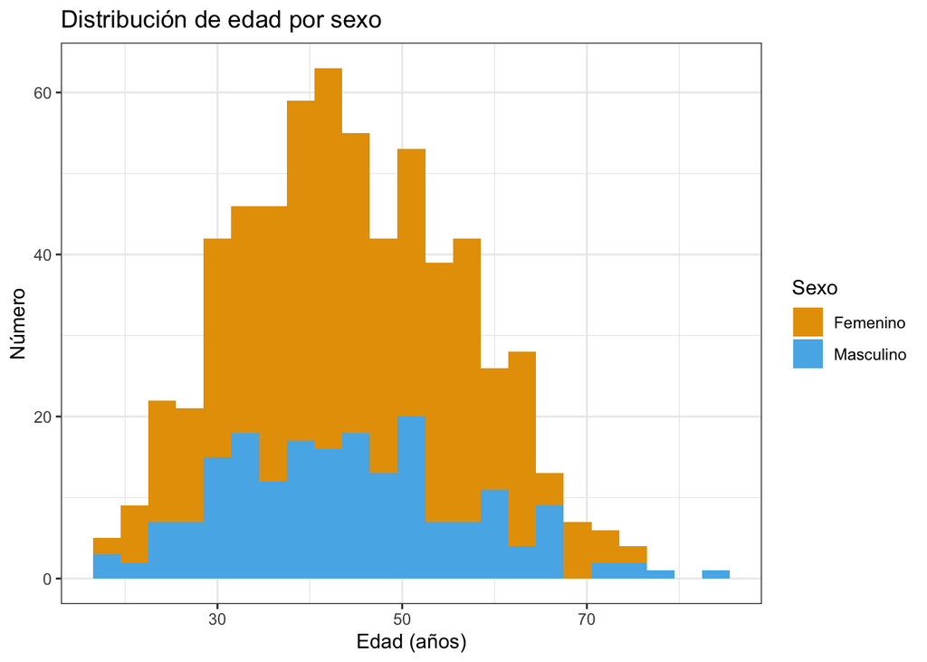

## Datos clínicos

A continuación, se presentan las características clínicas básicas de los pacientes.

### Edad y forma de inicio

La edad promedio (desviación estándar) de inicio de la enfermedad es de 32.3 (10.4) años. La mayoría de los pacientes (91.4%) han debutado con un curso en recaídas y remisiones, mientras que el resto lo han hecho en forma de EM primaria progresiva.

La edad de inicio difiere en los pacientes con un debut en forma de EM primaria progresiva (EMPP - 40.6 años) en comparación con quienes debutan en formas recurrentes de la EM (EMRR - 31.6 años), como se puede ver en la figura:

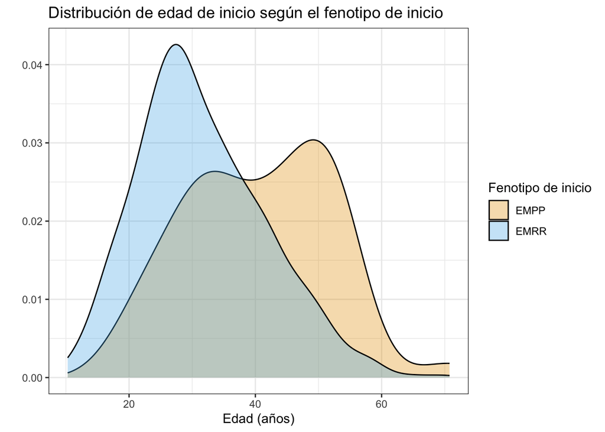

Las topografías del SNC en el momento del debut han sido supratentoriales en 52 (8.3%), de fosa posterior en 129 (20.5%), médula espinal en 302 (47.9%) y vías ópticas en 120 (19%).

La distribución de las topografías de inicio según el fenotipo de inicio se muestran a continuación:

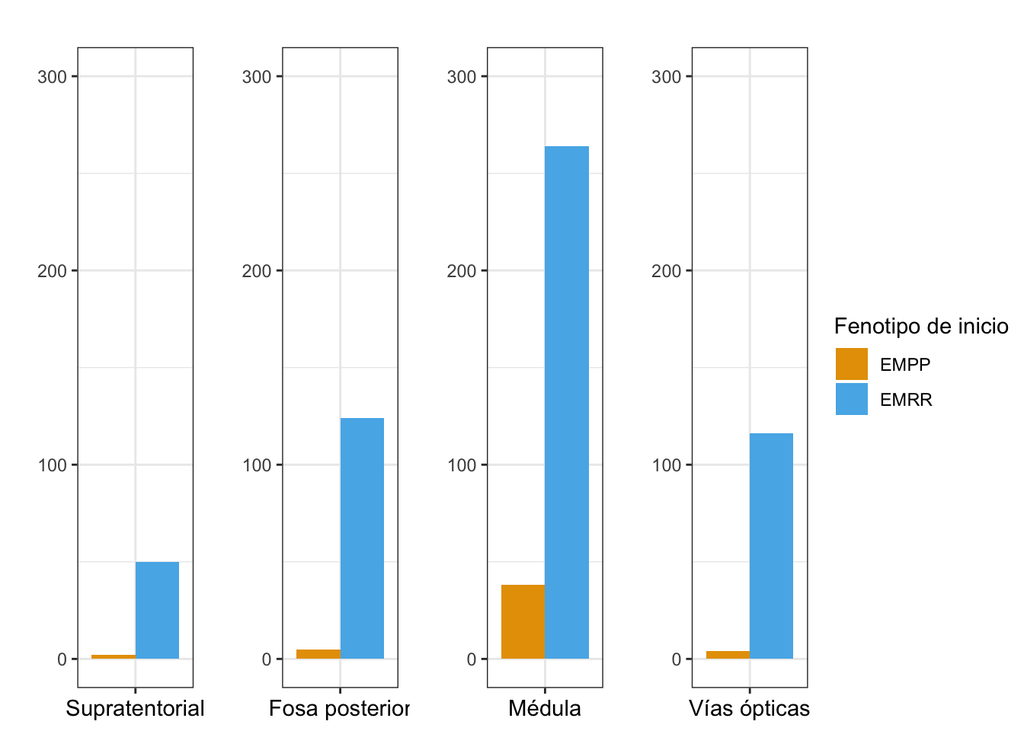

### Recaídas

Las recaídas son muy comunes en las manifestaciones de la EM. La mayoría de los pacientes en nuestro registro tiene una forma recurrente de la enfermedad. La tasa anual de recaídas (TAR) en general en la muestra de nuestro registro es 0.19 recaídas por paciente por año. Esto incluye tanto la información sobre las recaídas recabada de forma retrospectiva (TAR: 0.25), como de forma prospectiva desde que inició el seguimiento de cada paciente (TAR: 0.08).

### Tratamiento

De los 630 pacientes incluidos en el registro, 557 (88.41%) están bajo tratamiento actualmente.

La distribución de los tratamientos se presenta a continuación:

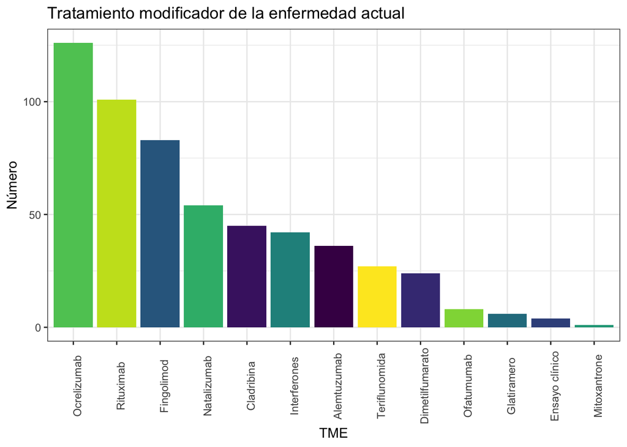

### Discapacidad

#### Estado actual de discapacidad

En el momento de la última evaluación, la mediana (rango intercuartílico) de EDSS era de 2.0 (1.0 - 3.5) puntos, con valores entre 0.0 y 9.5.0

La distribución de puntajes de EDSS se muestra a continuación.

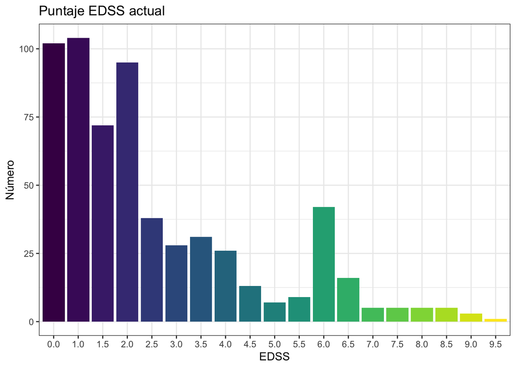

#### Discapacidad a lo largo del tiempo

El comportamiento de EDSS a lo largo del tiempo se muestra en la figura a continuación. En esta, cada línea corresponde a un paciente y cada punto a una determinación de EDSS. En el eje horizontal se muestran los meses transcurridos desde la primera visita al centro.

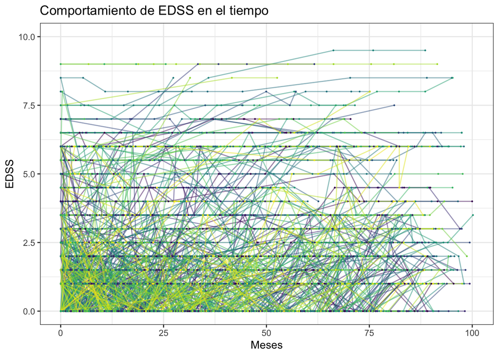

### Respuesta al tratamiento

A continuación se presentan los datos de recaídas y de discapacidad bajo los diferentes TME de forma individual. Únicamente se presentan los datos que han sido recolectados desde la primera visita en nuestro centro en adelante.

#### Interferones

##### Recaídas

69 pacientes han estado expuestos a interferones bajo el cuidado en nuestro centro, con una media (SD) de 22.1 (18.5) y un total de 1678 meses de observación de la exposición a este grupo de medicamentos. Durante este tiempo se observaron 13 recaídas, en 11 pacientes, para una TAR de 0.093.

##### Discapacidad

En los 69 pacientes observados bajo el tratamiento con interferones, se han hecho 298 determinaciones de EDSS.

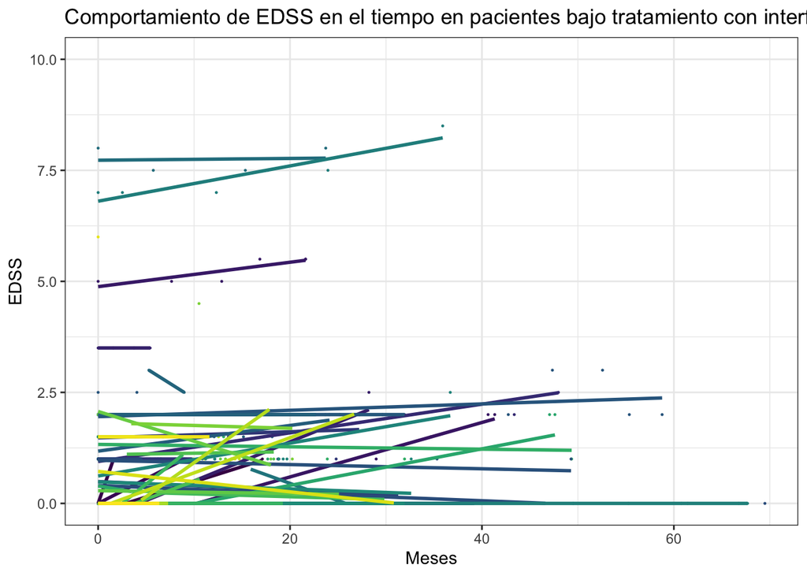

#### Glatiramero

##### Recaídas

15 pacientes han estado expuestos a glatiramero bajo el cuidado en nuestro centro, con una media (SD) de 22.5 (19.6) y un total de 361 meses de observación de la exposición a este medicamento. Durante este tiempo se observaron 3 recaídas, en 3 pacientes, para una TAR de 0.1.

##### Discapacidad

En los 15 pacientes observados bajo el tratamiento con glatiramero, se han hecho 56 determinaciones de EDSS.

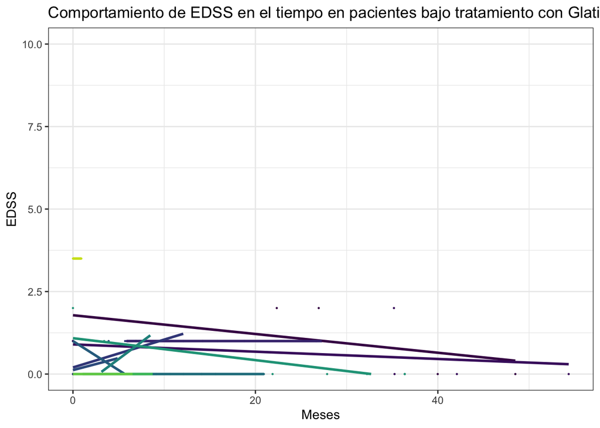

#### Teriflunomida

##### Recaídas

19 pacientes han estado expuestos a teriflunomida bajo el cuidado en nuestro centro, con una media (SD) de 26.3 (23) y un total de 499 meses de observación de la exposición a este medicamento. Durante este tiempo se observaron 3 recaídas, en 3 pacientes, para una TAR de 0.072.

##### Discapacidad

En los 19 pacientes observados bajo el tratamiento con teriflunomida, se han hecho 81 determinaciones de EDSS.

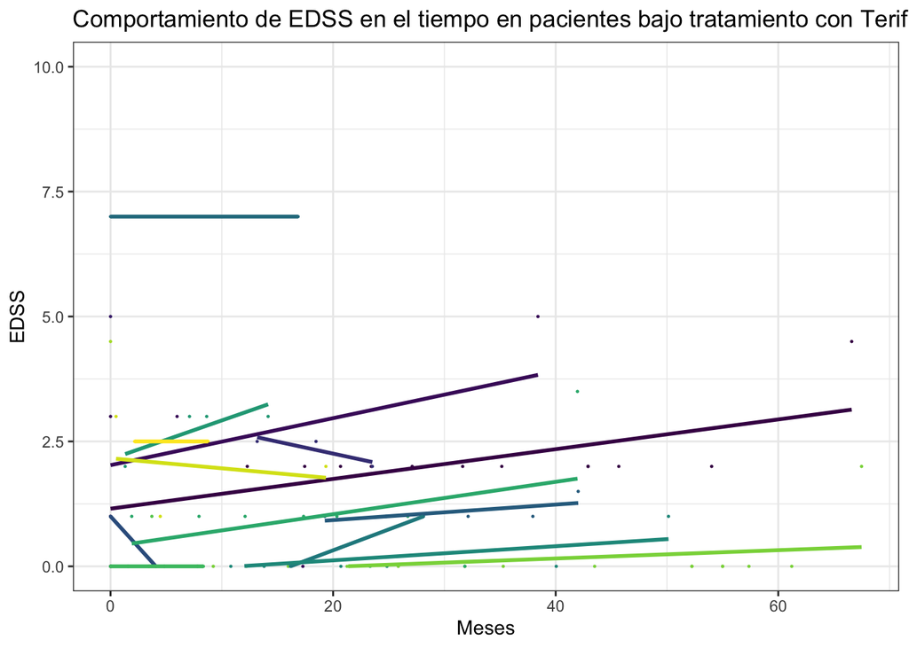

#### Dimetilfumarato

##### Recaídas

27 pacientes han estado expuestos a dimetilfumarato bajo el cuidado en nuestro centro, con una media (SD) de 26.3 (20.8) y un total de 710 meses de observación de la exposición a este medicamento. Durante este tiempo se observaron 12 recaídas, en 10 pacientes, para una TAR de 0.203.

##### Discapacidad

En los 27 pacientes observados bajo el tratamiento con dimetilfumarato, se han hecho 107 determinaciones de EDSS.

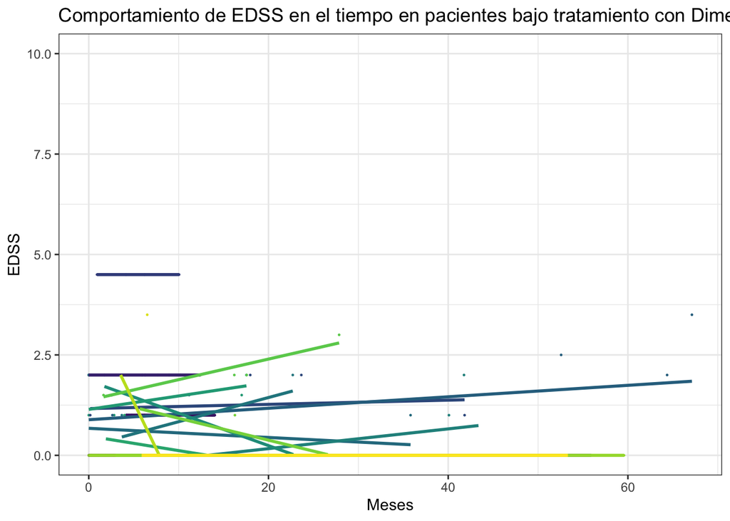

#### Fingolimod

##### Recaídas

70 pacientes han estado expuestos a fingolimod bajo el cuidado en nuestro centro, con una media (SD) de 26.2 (19.6) y un total de 1889 meses de observación de la exposición a este medicamento. Durante este tiempo se observaron 32 recaídas, en 27 pacientes, para una TAR de 0.203.

##### Discapacidad

En los 70 pacientes observados bajo el tratamiento con fingolimod, se han hecho 380 determinaciones de EDSS.

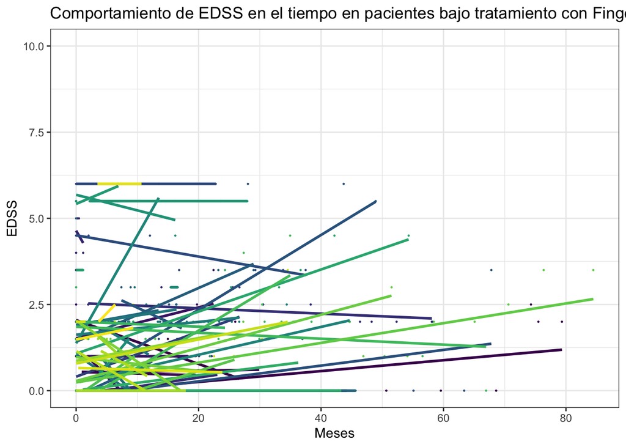

#### Cladribina

##### Recaídas

44 pacientes han estado expuestos a cladribina bajo el cuidado en nuestro centro, con una media (SD) de 21.1 (11.3) y un total de 2767 meses de observación de la exposición a este medicamento. Durante este tiempo se observaron 27 recaídas, en 6 pacientes, para una TAR de 0.117.

##### Discapacidad

En los 44 pacientes observados después del tratamiento con cladribina, se han hecho 366 determinaciones de EDSS.

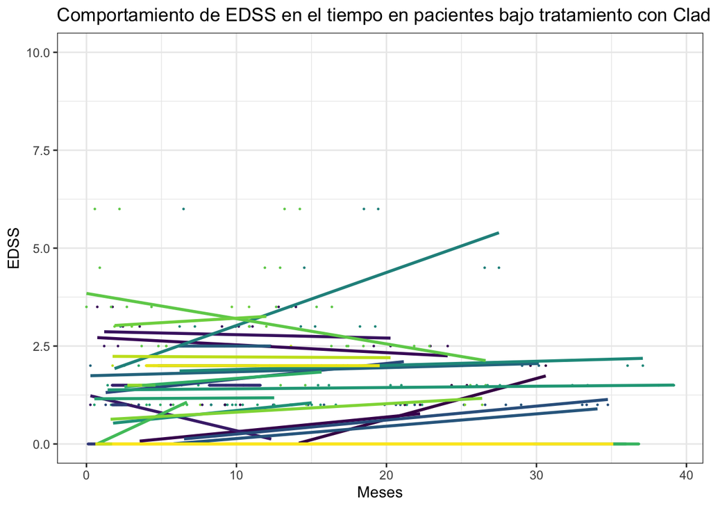

#### Natalizumab

##### Recaídas

68 pacientes han estado expuestos a natalizumab bajo el cuidado en nuestro centro, con una media (SD) de 26.7 (21) y un total de 1951 meses de observación de la exposición a este medicamento. Durante este tiempo se observaron 13 recaídas, en 12 pacientes, para una TAR de 0.08.

##### Discapacidad

En los 68 pacientes observados bajo el tratamiento con natalizumab, se han hecho 336 determinaciones de EDSS.

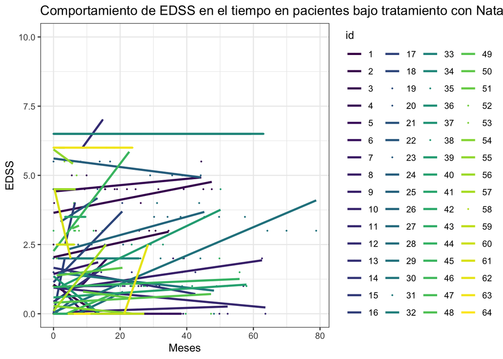

#### Alemtuzumab

##### Recaídas

47 pacientes han estado expuestos a alemtuzumab bajo el cuidado en nuestro centro, con una media (SD) de 46.5 (22) y un total de 4275 meses de observación de la exposición a este medicamento. Durante este tiempo se observaron 72 recaídas, en 23 pacientes, para una TAR de 0.202.

##### Discapacidad

En los 47 pacientes observados después del tratamiento con alemtuzumab, se han hecho 675 determinaciones de EDSS.

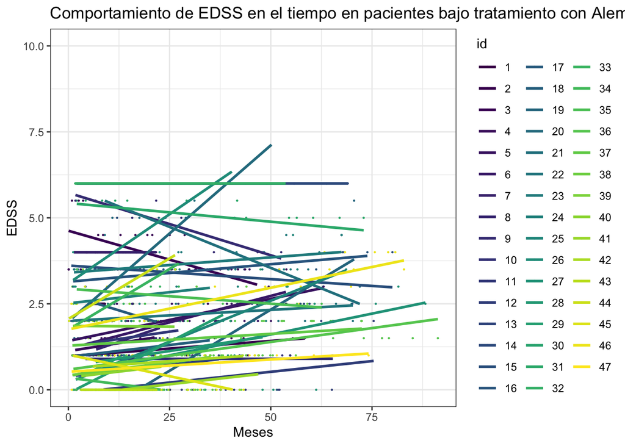

#### Rituximab

##### Recaídas

102 pacientes han estado expuestos a rituximab bajo el cuidado en nuestro centro, con una media (SD) de 18 (20.7) y un total de 1837 meses de observación de la exposición a este medicamento. Durante este tiempo se observaron 8 recaídas, en 6 pacientes, para una TAR de 0.052.

##### Discapacidad

En los 102 pacientes observados bajo el tratamiento con rituximab, se han hecho 279 determinaciones de EDSS.

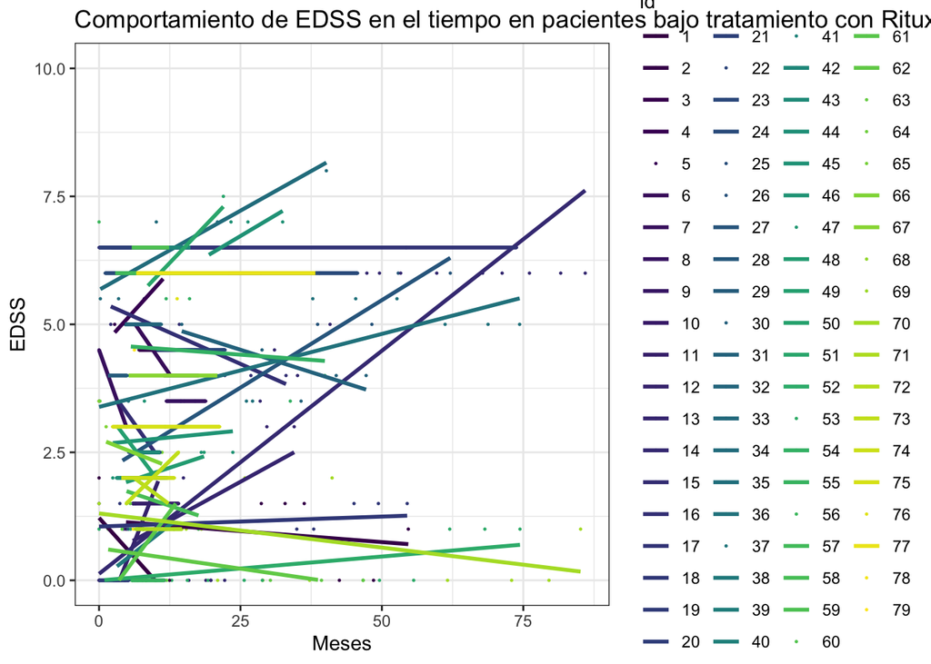

#### Ocrelizumab

##### Recaídas

126 pacientes han estado expuestos a ocrelizumab bajo el cuidado en nuestro centro, con una media (SD) de 22.7 (17.7) y un total de 2886 meses de observación de la exposición a este medicamento. Durante este tiempo se observaron 11 recaídas, en 9 pacientes, para una TAR de 0.046.

##### Discapacidad

En los 126 pacientes observados bajo el tratamiento con ocrelizumab, se han hecho 389 determinaciones de EDSS.

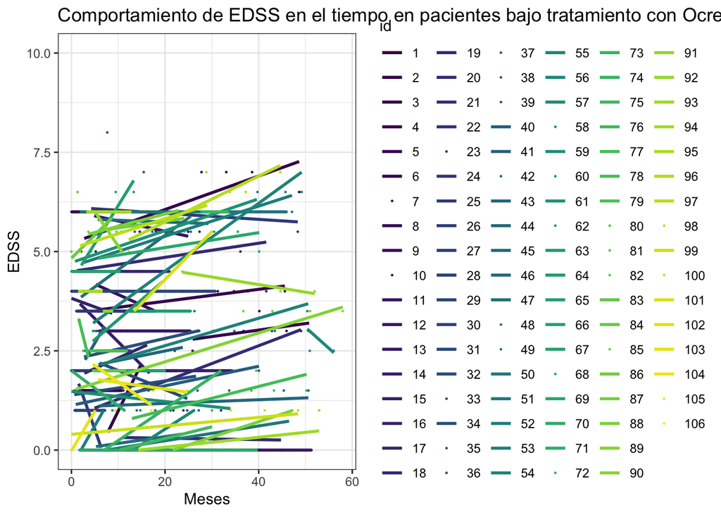

#### Ofatumumab

##### Recaídas

8 pacientes han estado expuestos a ofatumumab bajo el cuidado en nuestro centro, con una media (SD) de 9.3 (8.2) y un total de 83 meses de observación de la exposición a este medicamento. Durante este tiempo se observaron 0 recaídas, en 0 pacientes, para una TAR de 0.

##### Discapacidad

En los 8 pacientes observados bajo el tratamiento con ofatumumab, se han hecho 18 determinaciones de EDSS.

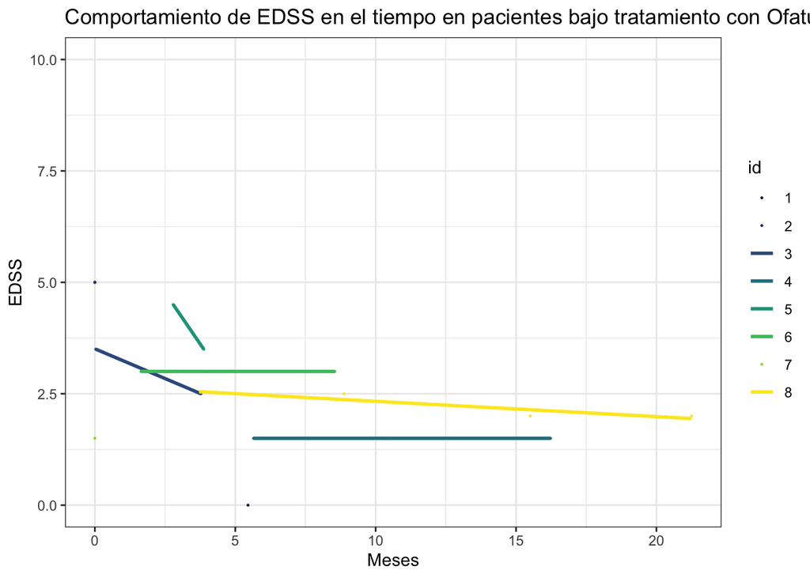

## Colaboración

Los datos del REMHUN no son públicos. Sin embargo, el equipo de investigación está disponible para realizar proyectos de investigación colaborativos. Este registro [hace parte](https://msda.emif-catalogue.eu/login?ref=c/msda/fingerprint/d7a96ebb66a2cb4eeff9cbe6b8ecf532/) del catálogo de la [Multiple Sclerosis Data Alliance](https://www.msdataalliance.org/cat/16/MSDA%20Catalogue). En caso de tener interés en colaborar, por favor escribir al correo investigacion.em@hun.edu.co.

## Financiación

Este proyecto ha sido posible con el apoyo de

[figure not shown]

a través de su filial [BIIB-Colombia](https://www.biibcolombia.co/).